# Jupyter Notebook on Docker

Install Docker for your operating system. **Note**: Windows Users are required to have WSL2 enabled to use Docker. Download the appropriate version from the [official website](https://docs.docker.com/get-docker/)

Ensure that the docker engine is running before the next step.

Type any one of the following commands in the directory where the notebook files are located.

**Note** : The first command is for the exercises that use Spark and Scikit-Learn packages. The second command is for Deep-Learning exercises. Make sure to run the correct command for the exercises, otherwise you may encounter errors while executing the notebooks.

`docker run -it --rm -p 8888:8888 -v "${PWD}":/home/jovyan/work jupyter/all-spark-notebook`

`docker run -it --rm -p 8888:8888 -v "${PWD}":/home/jovyan/work toluclassics/transformers_notebook`

**Note** : The string ${PWD} allows the present working directory in your local machine to be avaliable to the docker container.

**Note** : In the initial Docker setup, you may need root rights to start the container. If permission is denied, try

`sudo docker run -it --rm -p 8888:8888 -v "${PWD}":/home/jovyan/work jupyter/all-spark-notebook`

OR

`sudo docker run -it --rm -p 8888:8888 -v "${PWD}":/home/jovyan/work toluclassics/transformers_notebook`

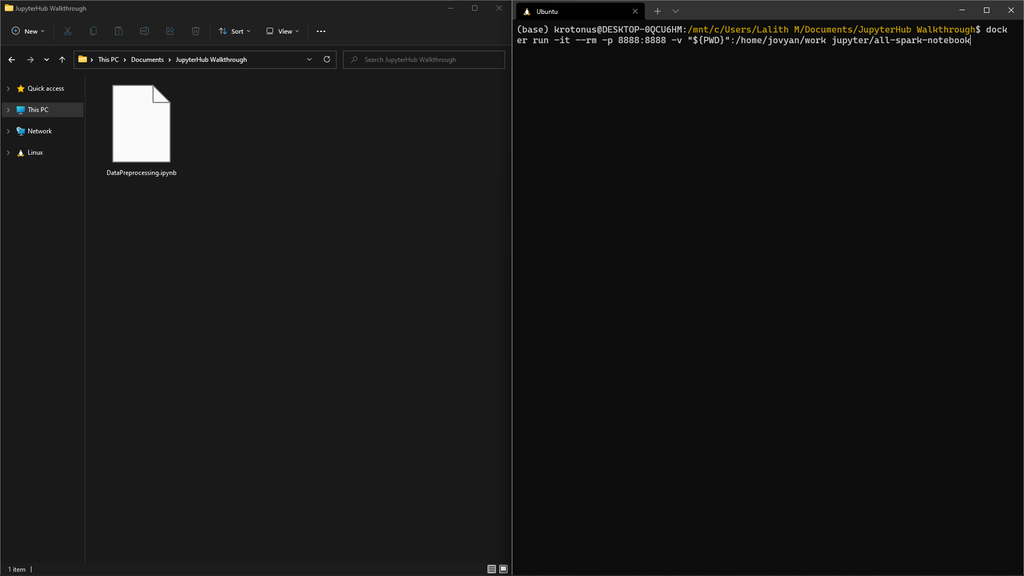

This should start a Jupyter Server instance and open your default browser automatically. Incase it does not, copy link given in the terminal and paste in your browser to start running your Jupyter server

[figure not shown]

You should then be able to see a folder which contains all the files that you have saved in your local machine.

[figure not shown]